# models

Alex Liu

2023-04-03

```r
library(EBImage)
library(tidyverse)
library(pracma)
library(randomForest)
library(ggimage)
```

# Random Forest (Pixel-Based)

```r
labels = list.files("../bio_data/Biotechnology/data_processed/cell_images/")
cell_boundaries_raw = read.csv("../bio_data/Biotechnology/data_processed/cell_boundaries.csv.gz")

cluster_ids = list()

for (i in 1:length(labels)) {

  cluster_file = list.files(paste0("../bio_data/Biotechnology/data_processed/cell_images/", labels[i]))

  cluster_ids[i] <- list(gsub(".*cell_|.png", "", cluster_file))
}

cluster_imgs = list()

for (i in 1:length(labels)) {

  cluster_file = list.files(paste0("../bio_data/Biotechnology/data_processed/cell_images/", labels[i]), full.names=T)

  cluster_imgs[i] <- list(sapply(cluster_file, readImage, simplify = F))

}
```

```r
get_inside = function(cellID, img, cell_boundaries) {

  cell_boundary = cell_boundaries |>
    filter(cell_id %in% cellID)

  # rescale the boundary according to the pixels
  pixels = dim(img)
  cell_boundary$vertex_x_scaled <- 1+((cell_boundary$vertex_x - min(cell_boundary$vertex_x))/0.2125)
  cell_boundary$vertex_y_scaled <- 1+((cell_boundary$vertex_y - min(cell_boundary$vertex_y))/0.2125)

  # identify which pixels are inside or outside of the cell segment using inpolygon
  pixel_locations = expand.grid(seq_len(nrow(img)), seq_len(ncol(img)))

  pixels_inside = inpolygon(x = pixel_locations[,1],
                            y = pixel_locations[,2],
                            xp = cell_boundary$vertex_x_scaled,
                            yp = cell_boundary$vertex_y_scaled,
                            boundary = TRUE)

  img_inside = img
  img_inside@.Data <- matrix(pixels_inside, nrow = nrow(img), ncol = ncol(img))

  return(img_inside)
}

mask_resize = function(img, img_inside, w = 50, h = 50) {

  img_mask = img*img_inside

  # then, transform the masked image to the same number of pixels, 50x50
  img_mask_resized = resize(img_mask, w, h)

  return(img_mask_resized)
}
```

```r
cluster_imgs_masked_resized = list()

for (i in 1:length(labels)) {
  cell_boundaries = cell_boundaries_raw |>
    filter(cell_id %in% cluster_ids[[i]])

  cluster_imgs_inside <- mapply(get_inside, cluster_ids[[i]], cluster_imgs[[i]], MoreArgs = list(cell_boundaries = cell_boundaries), SIMPLIFY = FALSE)

  cluster_imgs_masked_resized[i] = list(mapply(mask_resize, cluster_imgs[[i]], cluster_imgs_inside, SIMPLIFY = FALSE))

}
```

```r
set.seed(6)

times = c()

for (i in 1:length(labels)) {
  times[i] = length(cluster_ids[[i]])
}

y = factor(rep(labels, times = times))
x = cbind(do.call(cbind, lapply(cluster_imgs_masked_resized[[1]],c)),
          do.call(cbind, lapply(cluster_imgs_masked_resized[[2]],c)))

for (i in 3:length(cluster_imgs_masked_resized)) {
  x = cbind(do.call(cbind, lapply(cluster_imgs_masked_resized[[i]], c)),
            x)
}

rf = randomForest(x = t(x), y = y)
rf
```

```
##
## Call:
##  randomForest(x = t(x), y = y)
##                Type of random forest: classification
##                      Number of trees: 500
## No. of variables tried at each split: 50
##
##         OOB estimate of  error rate: 92.2%
## Confusion matrix:
##            cluster_1 cluster_10 cluster_11 cluster_12 cluster_13 cluster_14
## cluster_1         21          8          2          4          1          2
## cluster_10        13          3          4          3          0          1
## cluster_11         2          0          2          0          1          2
## cluster_12         3          2          5          3          1          1
## cluster_13         6          1          2          1          4          0
## cluster_14         9          1          1          5          0          1
## cluster_15         4          0          0          2          0          1
## cluster_16         4          0          1          1          1          0
## cluster_17         4          0          4          0          0          0
## cluster_18         4          1          0          1          1          1
## cluster_19         4          0          0          0          1          1
## cluster_2         19          3          3          2          6          2
## cluster_20         1          1          1          0          0          2
## cluster_21         4          0          3          0          1          0
## cluster_22         5          0          0          0          2          0
## cluster_23         3          0          0          1          0          0
## cluster_24         1          0          0          1          1          1
## cluster_25         2          0          1          0          1          0
## cluster_26         1          0          1          0          0          0
## cluster_27         1          0          1          1          0          0
## cluster_28         3          0          0          0          0          0
## cluster_3         19          2          2          4          2          1
## cluster_4         19          4          3          5          2          2
## cluster_5         16          2          3          3          1          0
## cluster_6         18          1          7          3          2          2
## cluster_7          7          0          4          3          3          4
## cluster_8          6          0          2          2          1          0
## cluster_9          5          0          4          2          0          1
##            cluster_15 cluster_16 cluster_17 cluster_18 cluster_19 cluster_2
## cluster_1           2          0          0          0          1        21
```

[output cut: 99 more lines]

```
## cluster_21         1         1         0         0   1.0000000
## cluster_22         3         1         0         0   1.0000000
## cluster_23         1         1         1         0   1.0000000
## cluster_24         0         0         0         0   1.0000000
## cluster_25         3         1         0         0   1.0000000
## cluster_26         1         1         0         0   1.0000000
## cluster_27         0         2         0         0   1.0000000
## cluster_28         0         0         0         0   1.0000000
## cluster_3          6         7         1         0   0.8767123
## cluster_4          6         1         1         0   0.8714286
## cluster_5          2         4         0         0   0.9344262
## cluster_6          3         4         1         0   0.9531250
## cluster_7          3         5         1         0   0.9218750
## cluster_8          5         9         1         0   0.9772727
## cluster_9          1         2         0         0   1.0000000
```

[figure not shown]

```r
importance_img = Image(data = matrix(rf$importance, 50, 50))
display(importance_img/quantile(importance_img, 0.99), method = "raster")
```

Possible Reasons for high error rate:

1. Inconsistent file size for different clusters.
2. Model not complex enough to capture more complex shapes.
3. Pixel intensities not normalised.
4. Cells not aligned with each other.

## Extracted features with cell boundary

```r
set.seed(66)
cluster_img_features = list()
xf = c()

for (i in 1:length(labels)) {
  cell_boundaries = cell_boundaries_raw |>
    filter(cell_id %in% cluster_ids[[i]])

  cluster_imgs_inside <- mapply(get_inside, cluster_ids[[i]], cluster_imgs[[i]], MoreArgs = list(cell_boundaries = cell_boundaries), SIMPLIFY = FALSE)

  cluster_img_features[i] <- list(mapply(computeFeatures,
                                x = cluster_imgs_inside,
                                ref = cluster_imgs[[i]],
                                MoreArgs = list(expandRef = NULL)))

  xf <- cbind(cluster_img_features[[i]], xf)

}

rff = randomForest(x = t(xf), y = y)
rff
```

```
##
## Call:
##  randomForest(x = t(xf), y = y)
##                Type of random forest: classification
##                      Number of trees: 500
## No. of variables tried at each split: 7
##
##         OOB estimate of  error rate: 90.5%
## Confusion matrix:
##            cluster_1 cluster_10 cluster_11 cluster_12 cluster_13 cluster_14
## cluster_1         22          6          4          3          1          4
## cluster_10        13          3          4          2          0          0
## cluster_11         6          0          6          2          1          0
## cluster_12         8          1          2          1          1          2
## cluster_13         9          0          0          2          1          2
## cluster_14         7          0          0          3          3          0
## cluster_15         1          0          3          1          1          1
## cluster_16         2          0          0          3          0          0
## cluster_17         3          0          3          1          1          1
## cluster_18         2          0          0          2          0          0
## cluster_19         4          0          0          0          0          1
## cluster_2          9          0          5          2          3          2
## cluster_20         2          0          1          0          0          1
## cluster_21         3          1          1          1          0          0
## cluster_22         1          0          1          0          1          0
## cluster_23         0          0          0          1          1          0
## cluster_24         1          0          0          1          0          1
## cluster_25         3          0          1          0          0          0
## cluster_26         1          0          0          2          0          0
## cluster_27         2          0          0          0          0          0
## cluster_28         2          1          0          1          1          0
## cluster_3         15          1          7          1          0          1
## cluster_4          8          4          4          2          3          1
## cluster_5          7          3          3          1          2          0
## cluster_6         10          4          5          2          2          2
## cluster_7          4          0          9          4          3          2
## cluster_8          7          0          0          3          3          2
## cluster_9          3          1          1          1          2          0
##            cluster_15 cluster_16 cluster_17 cluster_18 cluster_19 cluster_2
## cluster_1           1          1          1          1          3         9
```

[output cut: 99 more lines]

```
## cluster_21         0         2         0         0   1.0000000
## cluster_22         5         1         0         0   1.0000000
## cluster_23         2         1         0         0   1.0000000
## cluster_24         0         1         1         0   1.0000000
## cluster_25         0         2         1         0   1.0000000
## cluster_26         1         3         0         0   1.0000000
## cluster_27         0         1         1         0   1.0000000
## cluster_28         0         0         0         0   1.0000000
## cluster_3          6         7         3         1   0.9315068
## cluster_4          3         3         2         1   0.8571429
## cluster_5          2         4         2         1   0.8032787
## cluster_6          9         1         3         0   0.8593750
## cluster_7          5        11         0         0   0.8281250
## cluster_8          3         3         3         0   0.9318182
## cluster_9          2         1         1         0   1.0000000
```

There is a very small improvement in error rate.

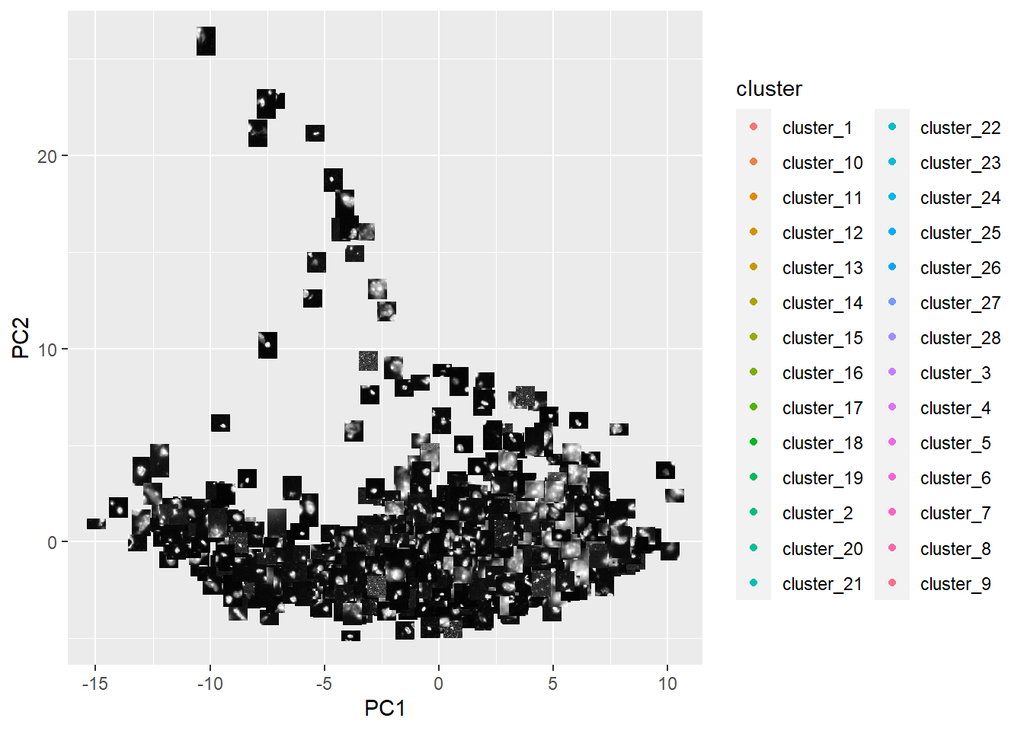

```r
images = c()
for (i in 1:length(labels)) {

  cluster_file = list.files(paste0("../bio_data/Biotechnology/data_processed/cell_images/", labels[i]), full.names = T)

  images <- append(images, cluster_file)
}

pc = princomp(t(xf), cor = T)

features_pc_df = data.frame(PC1 = pc$scores[, 1],
                            PC2 = pc$scores[, 2],
                            cluster = y,
                            images = images)

ggplot(features_pc_df, aes(x = PC1, y = PC2)) +
  geom_point(aes(colour = cluster)) +
  geom_image(aes(image = images), size=0.03)
```

Despite the high error% of the random forest model, there is still a noticeable distance between high and low intensity images.

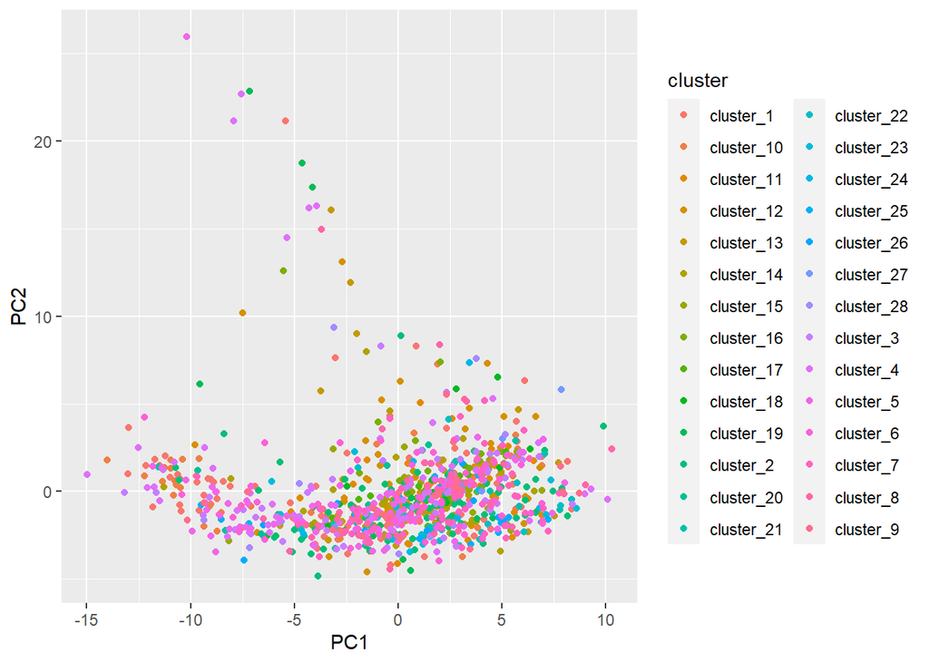

```r
ggplot(features_pc_df, aes(x = PC1, y = PC2)) +
  geom_point(aes(colour = cluster))
```

However, it may be difficult to use PCA loading to interpret the extracted features associated with the visual characteristics.

## Is there a difference for Random Forest without the use of cell boundary

```r
set.seed(61)
xnobound = c()

for (i in 1:length(cluster_imgs)) {
  xnobound = cbind(do.call(cbind, lapply(cluster_imgs_masked_resized[[i]], c)),
            xnobound)
}

rf = randomForest(x = t(xnobound), y = y)
rf
```

```
##
## Call:
##  randomForest(x = t(xnobound), y = y)
##                Type of random forest: classification
##                      Number of trees: 500
## No. of variables tried at each split: 50
##
##         OOB estimate of  error rate: 89.8%
## Confusion matrix:
##            cluster_1 cluster_10 cluster_11 cluster_12 cluster_13 cluster_14
## cluster_1         28          7          2          3          1          0
## cluster_10        14          5          1          3          0          2
## cluster_11         5          1          1          1          2          0
## cluster_12         5          2          3          2          2          2
## cluster_13         5          1          1          1          3          1
## cluster_14         8          1          2          2          0          1
## cluster_15         5          0          0          1          0          0
## cluster_16         3          0          2          1          0          1
## cluster_17         3          0          2          0          1          1
## cluster_18         2          1          0          1          1          1
## cluster_19         5          0          0          0          0          1
## cluster_2         13          2          2          2          2          5
## cluster_20         3          0          1          0          0          0
## cluster_21         3          0          3          0          0          0
## cluster_22         2          0          1          0          2          0
## cluster_23         3          0          0          1          1          0
## cluster_24         2          1          0          1          0          0
## cluster_25         3          0          1          0          1          0
## cluster_26         1          0          0          0          0          0
## cluster_27         1          0          2          0          0          0
## cluster_28         2          1          1          1          0          0
## cluster_3         18          4          2          2          0          5
## cluster_4         17          4          3          1          2          1
## cluster_5         15          2          0          3          1          1
## cluster_6         11          0          2          1          1          0
## cluster_7          9          0          5          4          1          4
## cluster_8          5          1          1          1          1          1
## cluster_9          5          1          1          1          0          1
##            cluster_15 cluster_16 cluster_17 cluster_18 cluster_19 cluster_2
## cluster_1           0          0          1          0          1        15
```

[output cut: 99 more lines]

```
## cluster_21         1         1         1         0   1.0000000
## cluster_22         2         3         0         0   1.0000000
## cluster_23         1         2         1         1   1.0000000
## cluster_24         0         0         1         0   1.0000000
## cluster_25         2         1         0         0   1.0000000
## cluster_26         2         0         0         0   1.0000000
## cluster_27         0         1         0         0   1.0000000
## cluster_28         1         0         0         0   1.0000000
## cluster_3         10         7         2         0   0.8904110
## cluster_4          3         8         0         0   0.8857143
## cluster_5          4         4         1         0   0.9016393
## cluster_6         12         5         2         0   0.8125000
## cluster_7          8         6         0         1   0.9062500
## cluster_8          4         6         1         0   0.9772727
## cluster_9          1         1         0         0   1.0000000
```

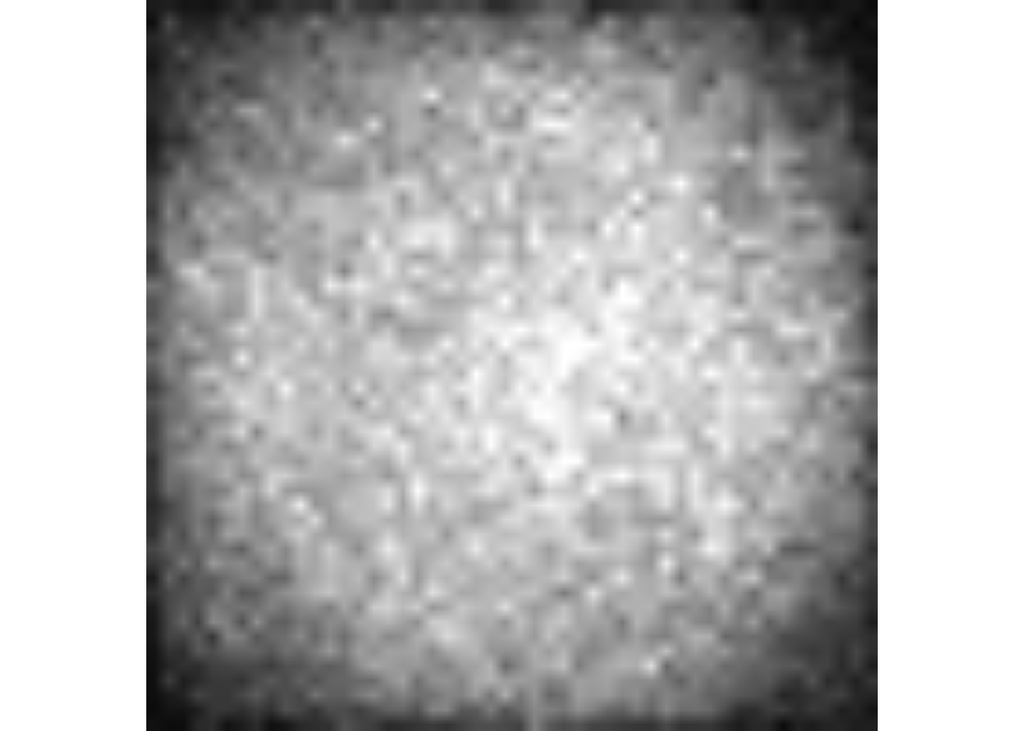

```r
importance_img = Image(data = matrix(rf$importance, 50, 50))
display(importance_img/quantile(importance_img, 0.99), method = "raster")
```

### Same random forest with extracted features

```r
set.seed(62)
cluster_img_features_nobound = list()
xfnobound = c()

for (i in 1:length(labels)) {
  cell_boundaries = cell_boundaries_raw |>
    filter(cell_id %in% cluster_ids[[i]])

  cluster_img_features[i] <- list(mapply(computeFeatures,
                                x = cluster_imgs[[i]],
                                ref = cluster_imgs[[i]],
                                MoreArgs = list(expandRef = NULL)))

  xfnobound <- cbind(cluster_img_features[[i]], xfnobound)

}

rff = randomForest(x = t(xfnobound), y = y)
rff
```

```
##
## Call:
##  randomForest(x = t(xfnobound), y = y)
##                Type of random forest: classification
##                      Number of trees: 500
## No. of variables tried at each split: 7
##
##         OOB estimate of  error rate: 90.6%
## Confusion matrix:
##            cluster_1 cluster_10 cluster_11 cluster_12 cluster_13 cluster_14
## cluster_1         34          2          3          2          0          1
## cluster_10        14          0          2          2          0          1
## cluster_11        15          0          1          2          1          0
## cluster_12         8          1          0          5          0          2
## cluster_13        15          0          3          1          0          0
## cluster_14        10          1          0          0          2          0
## cluster_15         7          0          0          0          0          0
## cluster_16         4          0          1          1          0          0
## cluster_17         3          0          1          1          0          0
## cluster_18         6          0          2          0          0          0
## cluster_19         4          0          0          0          0          0
## cluster_2         22          1          3          5          0          1
## cluster_20         4          1          0          0          0          0
## cluster_21         3          0          0          0          0          0
## cluster_22         6          0          0          0          0          0
## cluster_23         6          0          0          1          0          0
## cluster_24         6          0          2          0          0          0
## cluster_25         2          0          1          0          0          0
## cluster_26         2          0          1          0          0          0
## cluster_27         1          0          0          2          0          0
## cluster_28         5          0          0          0          0          0
## cluster_3         21          0          1          3          0          2
## cluster_4         29          3          1          3          1          0
## cluster_5         25          1          1          2          0          0
## cluster_6         18          0          1          4          0          0
## cluster_7         14          0          3          3          2          0
## cluster_8         14          0          1          3          0          0
## cluster_9         10          0          0          2          0          0
##            cluster_15 cluster_16 cluster_17 cluster_18 cluster_19 cluster_2
## cluster_1           0          0          0          0          1        30
```

[output cut: 99 more lines]

```
## cluster_21         2         0         0         0   1.0000000
## cluster_22         3         0         0         0   1.0000000
## cluster_23         2         1         0         0   1.0000000
## cluster_24         0         0         0         0   1.0000000
## cluster_25         2         1         0         0   1.0000000
## cluster_26         2         0         0         0   1.0000000
## cluster_27         0         0         0         0   1.0000000
## cluster_28         0         1         0         0   1.0000000
## cluster_3          7         6         0         0   0.9178082
## cluster_4          5         0         2         1   0.9571429
## cluster_5          3         2         1         0   0.9180328
## cluster_6          9         5         0         0   0.8593750
## cluster_7          6         3         0         1   0.9531250
## cluster_8          5         0         1         0   0.9772727
## cluster_9          2         2         0         0   1.0000000
```

Similar error rate. It did get better at identifying images in clusters 1 and 2, however, it came at the expense of identifying other clusters.